# Novel Coronavirus 2019 Project

Yixiao Jiang & Shaohan Wang

April 24th, 2020

## Introduction

**With the spreading of coronavirus, we are interested in the current condition of the spreading and which factors might impact the spread of COVID-19 virus. Some key factors we focused on are temperature and humidity.**

Two major data sources used in the analysis are found in Kaggle:

1. The covid_19_data dataset was extracted from the Johns Hopkins University and it continuously updates. It was collected to predict how and when the virus would end and provide timely condition of the spreading of the virus to the public. https://www.kaggle.com/sudalairajkumar/novel-corona-virus-2019-dataset
2. The covid19_weather_data dataset was made with the weather data collected from World Weather Online API and was inspired by Weather Impact on COVID19 Spread by JHU. It was collected to help understand of COVID19 and viral transmission by some important climate features. https://www.kaggle.com/hbfree/covid19formattedweatherjan22march24

One other data sources used in the analysis:  
The GlobalLandTemperatureByCountry dataset contains very clear and detailed temperature information since 1743 for each country in each month.

## Analysis Method

### Data Preparation

Uploading relevant packages and inpecting datasets:

```r
rm(list = ls())
#Relevant packages
library(readr)
library(DataComputing)
library(dplyr)
library(ggplot2)
library(tidyr)
#Access datasets
covid_19_data <- read_csv("covid_19_data.csv")
covid19_weather_data <- read.csv("covid19_weather_data.csv")

#Inspect datasets
# no. of case in covid_19_data & covid19_weather_data
nrow(covid_19_data)
```

```
[1] 11299
```

```r
nrow(covid19_weather_data)
```

```
[1] 18056
```

```r
#variables and structure of datasets
str(covid_19_data)
```

```
Classes ‘spec_tbl_df’, ‘tbl_df’, ‘tbl’ and 'data.frame':    11299 obs. of  8 variables:
 $ SNo            : num  1 2 3 4 5 6 7 8 9 10 ...
 $ ObservationDate: chr  "01/22/2020" "01/22/2020" "01/22/2020" "01/22/2020" ...
 $ Province/State : chr  "Anhui" "Beijing" "Chongqing" "Fujian" ...
 $ Country/Region : chr  "Mainland China" "Mainland China" "Mainland China" "Mainland China" ...
 $ Last Update    : chr  "1/22/2020 17:00" "1/22/2020 17:00" "1/22/2020 17:00" "1/22/2020 17:00" ...
 $ Confirmed      : num  1 14 6 1 0 26 2 1 4 1 ...
 $ Deaths         : num  0 0 0 0 0 0 0 0 0 0 ...
 $ Recovered      : num  0 0 0 0 0 0 0 0 0 0 ...
 - attr(*, "spec")=
  .. cols(
  ..   SNo = col_double(),
  ..   ObservationDate = col_character(),
  ..   `Province/State` = col_character(),
  ..   `Country/Region` = col_character(),
  ..   `Last Update` = col_character(),
  ..   Confirmed = col_double(),
  ..   Deaths = col_double(),
  ..   Recovered = col_double()
  .. )
```

```r
str(covid19_weather_data)
```

```
'data.frame':   18056 obs. of  22 variables:
 $ Province.State: Factor w/ 133 levels "","Alabama","Alaska",..: 1 1 1 1 1 1 1 1 1 1 ...
 $ Country.Region: Factor w/ 171 levels "Afghanistan",..: 1 1 1 1 1 1 1 1 1 1 ...
 $ lat           : num  33 33 33 33 33 33 33 33 33 33 ...
 $ long          : num  65 65 65 65 65 65 65 65 65 65 ...
 $ day           : int  0 1 2 3 4 5 6 7 8 9 ...
 $ pop           : int  38928346 38928346 38928346 38928346 38928346 38928346 38928346 38928346 38928346 38928346 ...
 $ urbanpop      : int  9732086 9732086 9732086 9732086 9732086 9732086 9732086 9732086 9732086 9732086 ...
 $ density       : int  60 60 60 60 60 60 60 60 60 60 ...
 $ medianage     : int  18 18 18 18 18 18 18 18 18 18 ...
 $ smokers       : num  -999 -999 -999 -999 -999 -999 -999 -999 -999 -999 ...
 $ tests         : int  -999 -999 -999 -999 -999 -999 -999 -999 -999 -999 ...
 $ testpop       : num  -999 -999 -999 -999 -999 -999 -999 -999 -999 -999 ...
 $ health_exp_pc : int  60 60 60 60 60 60 60 60 60 60 ...
 $ hospibed      : num  0.5 0.5 0.5 0.5 0.5 0.5 0.5 0.5 0.5 0.5 ...
 $ quarantine    : int  -999 -999 -999 -999 -999 -999 -999 -999 -999 -999 ...
 $ schools       : int  -999 -999 -999 -999 -999 -999 -999 -999 -999 -999 ...
 $ restrictions  : int  -999 -999 -999 -999 -999 -999 -999 -999 -999 -999 ...
 $ temperature   : int  4 4 4 6 5 5 3 4 4 5 ...
 $ humidity      : int  75 63 92 84 62 62 47 40 35 38 ...
 $ confirmed     : int  0 0 0 0 0 0 0 0 0 0 ...
 $ deaths        : int  0 0 0 0 0 0 0 0 0 0 ...
 $ recovered     : int  0 0 0 0 0 0 0 0 0 0 ...
```

```r
head(covid_19_data)
```

```
# A tibble: 6 x 8
    SNo ObservationDate `Province/State` `Country/Region`
  <dbl> <chr>           <chr>            <chr>
1     1 01/22/2020      Anhui            Mainland China
2     2 01/22/2020      Beijing          Mainland China
3     3 01/22/2020      Chongqing        Mainland China
4     4 01/22/2020      Fujian           Mainland China
5     5 01/22/2020      Gansu            Mainland China
6     6 01/22/2020      Guangdong        Mainland China
# … with 4 more variables: `Last Update` <chr>, Confirmed <dbl>,
#   Deaths <dbl>, Recovered <dbl>
```

```r
head(covid19_weather_data)
```

```
  Province.State Country.Region lat long day      pop urbanpop
1                   Afghanistan  33   65   0 38928346  9732086
2                   Afghanistan  33   65   1 38928346  9732086
3                   Afghanistan  33   65   2 38928346  9732086
4                   Afghanistan  33   65   3 38928346  9732086
5                   Afghanistan  33   65   4 38928346  9732086
6                   Afghanistan  33   65   5 38928346  9732086
  density medianage smokers tests testpop health_exp_pc hospibed
1      60        18    -999  -999    -999            60      0.5
2      60        18    -999  -999    -999            60      0.5
3      60        18    -999  -999    -999            60      0.5
4      60        18    -999  -999    -999            60      0.5
5      60        18    -999  -999    -999            60      0.5
6      60        18    -999  -999    -999            60      0.5
  quarantine schools restrictions temperature humidity confirmed
1       -999    -999         -999           4       75         0
2       -999    -999         -999           4       63         0
3       -999    -999         -999           4       92         0
4       -999    -999         -999           6       84         0
5       -999    -999         -999           5       62         0
6       -999    -999         -999           5       62         0
  deaths recovered
1      0         0
2      0         0
3      0         0
4      0         0
5      0         0
6      0         0
```

For covid19_weather_data, the case represents an individual province/state of different countries in each of the 60 days with detailed covid-19 cases information and local weather features. There are 18056 cases. There are a total of 22 variables, and we will use “Province.State”, “Country.Region”, “temperature” and “humidity” to proceed and solve the project questions.

### Data Wrangling & Data Visualization

**1. Compare COVID-19 Cases with Average Global Temperature**

*Data Wrangling*

```r
# Covid_19_data
NewData <- covid_19_data[ ,c(4,6,7,8)]
# Create data table grouped by country
SummaryStats <-
  NewData %>%
  group_by(`Country/Region`) %>%
  summarise(confirmed = sum(Confirmed), death = sum(Deaths),
            recovered = sum(Recovered))
SummaryStats <- rename(SummaryStats, Country= `Country/Region`)
# Load global average temperature dataset
GlobalLandTemperaturesByCountry <- read_csv("GlobalLandTemperaturesByCountry.csv")
# Investigate past average temerature by countries
Tempt_avg <-
  GlobalLandTemperaturesByCountry %>%
  group_by(Country) %>%
  summarise(temp = mean(na.omit(AverageTemperature)))
US <-c("US","11.49")
Tempt_avg <- rbind(Tempt_avg, US)
# Combine dataset tempt vs COVID cases
COVID_tempt <-
  left_join(SummaryStats, Tempt_avg)
n <- nrow(COVID_tempt)
# Delete Country if temerature is unknown
for(i in 1:n){
  if(is.na(COVID_tempt$temp[i])){
    COVID_tempt = COVID_tempt[-i, ]
  }
  else{
    COVID_tempt$temp[i] = COVID_tempt$temp[i]
  }
}
COVID_tempt$temp <- as.numeric(COVID_tempt$temp)
# Inspect dataset
head(COVID_tempt)
```

```
# A tibble: 6 x 5
  Country     confirmed death recovered  temp
  <chr>           <dbl> <dbl>     <dbl> <dbl>
1 Afghanistan      1735    39        41  14.0
2 Albania          2768   122       384  12.6
3 Algeria          6661   468       716  23.0
4 Andorra          3605    68        57  11.2
5 Angola             64    10         3  21.8
6 Argentina        8681   222      1427  14.6
```

```r
# Simplified dataset
COVID_tempt_combined <-
  COVID_tempt %>%
  gather(key = condition, value = casesnum, confirmed,death,recovered)
# Inspect dataset
head(COVID_tempt_combined)
```

```
# A tibble: 6 x 4
  Country      temp condition casesnum
  <chr>       <dbl> <chr>        <dbl>
1 Afghanistan  14.0 confirmed     1735
2 Albania      12.6 confirmed     2768
3 Algeria      23.0 confirmed     6661
4 Andorra      11.2 confirmed     3605
5 Angola       21.8 confirmed       64
6 Argentina    14.6 confirmed     8681
```

*Data Visualization*

```
Mapping API still under development and may change in future releases.
1 items were not translated
```

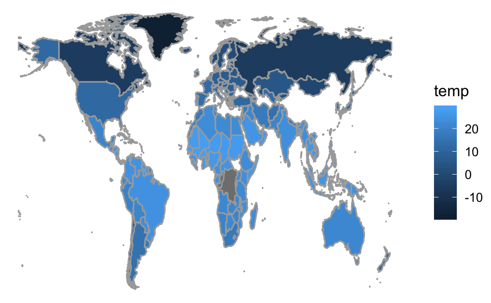

```r
# World Map with average temerature
WorldMap(COVID_tempt, key = Country, fill = temp)
```

```
Mapping API still under development and may change in future releases.
1 items were not translated
```

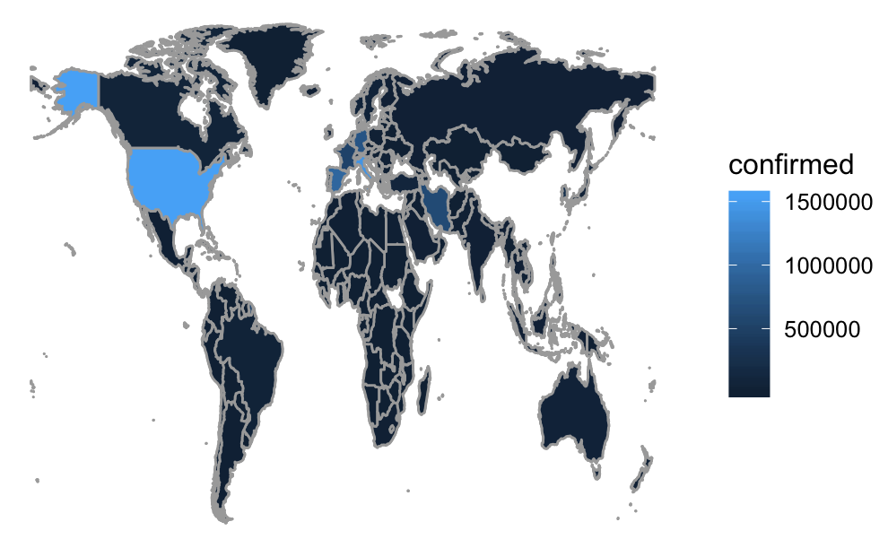

```r
# World Map of reported COVID cases
WorldMap(COVID_tempt, key = Country, fill = confirmed)
```

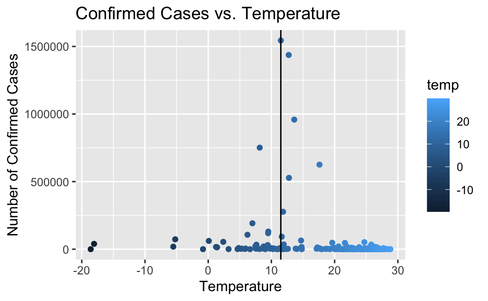

```r
# Graph of no. of cases vs its corresponding temperature
graph <- ggplot(data = COVID_tempt, aes(x = temp, y = confirmed))
layer1 <- geom_point(data = COVID_tempt, aes(color = temp))
layer2 <- geom_vline(xintercept = 11.49)
graph + layer1 + layer2 +xlab('Temperature') +
  ylab('Number of Confirmed Cases') +
  ggtitle('Confirmed Cases vs. Temperature')
```

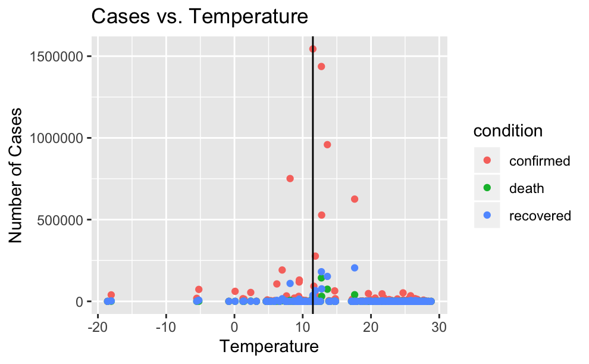

```r
# Graph combine three conditions
graph <- ggplot(data = COVID_tempt_combined, aes(x = temp, y = casesnum))
layer1 <- geom_point(data = COVID_tempt_combined, aes(color = condition))
layer2 <- geom_vline(xintercept = 11.49)
graph + layer1 + layer2 +xlab('Temperature') +
  ylab('Number of Cases') +
  ggtitle('Cases vs. Temperature')
```

- We use “covid_19_data” as the primary data source and joined it by data table “GlobalLandTemperatureByCountry” with detailed temperature information in different countries.
- In order to investigate on the relationship between temperature and number of reported infected cases, we plot two variables on different maps. Since US has extreme number of cases in this dataset which makes it hard to distinguish from other countries, we plot another point graph to show the relationship between temperature and number of reported cases.
- From the graphs, we could observe that the number of cases become extremely bigger when the temperature approaches around 12 Celsius. And it becomes stable when the temperature increases.

**2. Compare COVID-19 Cases with Humidity**

*Data Wrangling*

```r
# covid19_weather_data
covid19_weather_data <-
  covid19_weather_data %>%
  filter(humidity > 0, confirmed > 0)

covid19_humidity_Hubei_China <-
  covid19_weather_data %>%
  filter(Province.State == 'Hubei') %>%
  select(Province.State, humidity, confirmed)

covid19_humidity_China <-
  covid19_weather_data %>%
  filter(Country.Region == 'China') %>%
  group_by(Country.Region, day) %>%
  summarise(humidity = mean(humidity, na.rm = TRUE),
            confirmed = sum(confirmed, na.rm = TRUE)) %>%
  select(Country.Region, humidity, confirmed)

covid19_humidity_Italy <-
  covid19_weather_data %>%
  filter(Country.Region == 'Italy') %>%
  select(Country.Region, humidity, confirmed)
```

*Data Visualization*

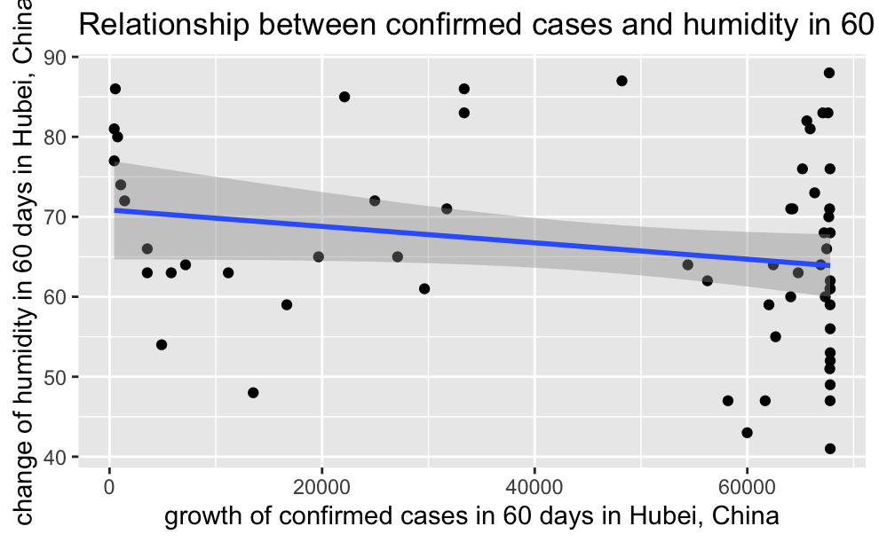

```r
# Scatterplot for Hubei, China
covid19_humidity_Hubei_China %>%
  ggplot(aes(x = confirmed, y = humidity)) +
  geom_point() +
  geom_smooth(method = 'lm') +
  xlab('growth of confirmed cases in 60 days in Hubei, China') +
  ylab('change of humidity in 60 days in Hubei, China') +
  ggtitle('Relationship between confirmed cases and humidity in 60 days in Hubei, China')
```

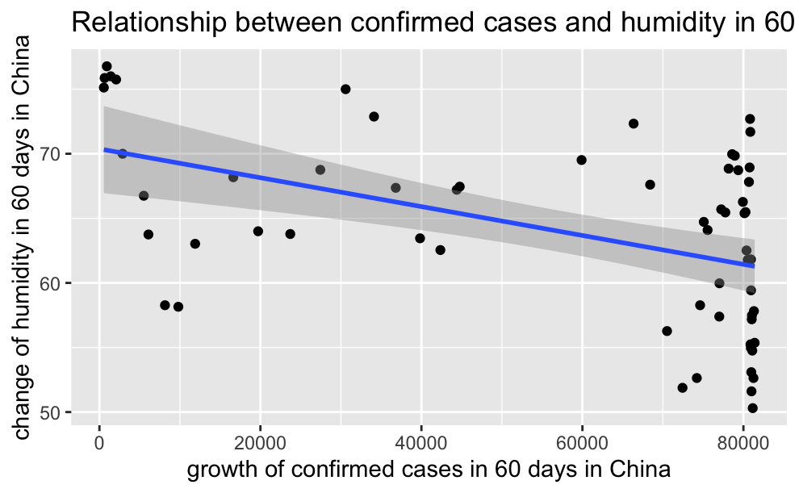

```r
# Scatterplot for China
covid19_humidity_China %>%
  ggplot(aes(x = confirmed, y = humidity)) +
  geom_point() +
  geom_smooth(method = 'lm') +
  xlab('growth of confirmed cases in 60 days in China') +
  ylab('change of humidity in 60 days in China') +
  ggtitle('Relationship between confirmed cases and humidity in 60 days in China')
```

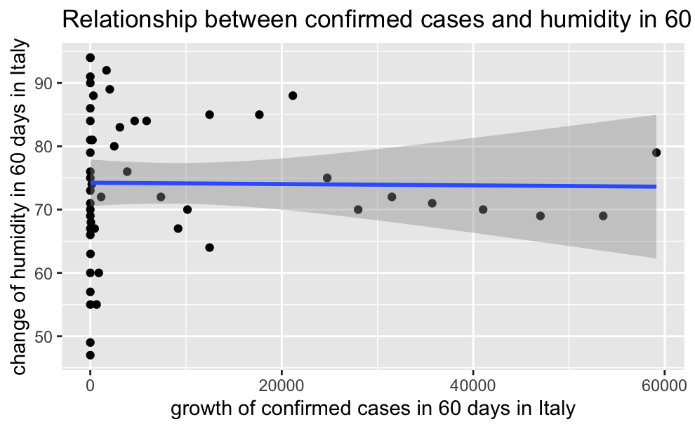

```r
# Scatterplot for Italy
covid19_humidity_Italy %>%
  ggplot(aes(x = confirmed, y = humidity)) +
  geom_point() +
  geom_smooth(method = 'lm') +
  xlab('growth of confirmed cases in 60 days in Italy') +
  ylab('change of humidity in 60 days in Italy') +
  ggtitle('Relationship between confirmed cases and humidity in 60 days in Italy')
```

- We use “covid19_weather_data” as the primary data source to test the relationship between the humidity level and the spread of Coronavirus.
- In order to investigate on the relationship between humidity and number of reported infected cases, we plot two variables on 3 scatterplots. And we choose Hubei of China, China and Italy to mainly focus on because they are severely influenced by the virus in these 60 days(from January 22 to March 24). The case of each graphs represents the information in one day.
- From the graphs, due to the large confidence interval which means high uncertainty, there is no clear correlation between growth of number of confirmed cases and the change of humidity in 60 days. Besides, days with relatively higher growth rate of the confirmed cases do not necessarily have high or low humidity levels at the same time.

## Conclusion

1. Temperature does have relationship or even is correlated with the spread of the coronavirus. And when the temperature is around 10 celsius, the cases happened most often.
2. Humidity does not have clear relationship or correlation with the spread of the coronovirus. But we did observe some minor relationships between these two factors in 60 days in China with high uncertainty.